# Data Description:

The Street View House Numbers (SVHN) Dataset SVHN is a real-world image dataset for developing machine learning and object recognition algorithms with minimal requirement on data formatting but comes from a significantly harder, unsolved, real world problem (recognizing digits and numbers in natural scene images). SVHN is obtained from house numbers in Google Street View images.

Link to the dataset: https://drive.google.com/file/d/1L2-WXzguhUsCArrFUc8EEkXcj33pahoS/view?usp=sharing

# Objective:

The objective of the project is to learn how to implement a simple image classification pipeline based on a deep neural network. The goals of this project are as follows:

Steps and tasks

1. Load Dataset
2. Understand the basic Image Classification pipeline and the data-driven approach (train/predict stages)
3. Data fetching and understand the train/val/test splits. (15 points)
4. Implement and apply a deep neural network classifier including (feedforward neural network, RELU, activations) (25 points)
5. Implement batch normalization for training the neural network(10 points)
6. Print the classification accuracy metrics (10 points)

# Load Dataset

```python
import pandas as pd
import numpy as np
from sklearn.model_selection import train_test_split
from sklearn import preprocessing
from sklearn.metrics import accuracy_score, confusion_matrix, precision_score, recall_score, f1_score, precision_recall_curve, auc
import matplotlib.pyplot as plt
%matplotlib inline
import tensorflow as tf
from keras.models import Sequential
from keras.layers import Activation, Dense
from keras import optimizers
from keras.layers import BatchNormalization, Dropout
```

```python
# Open file as readonly
import h5py
h5f = h5py.File('SVHN_single_grey1.h5', 'r')
```

```python
h5f.keys()
```

```
<KeysViewHDF5 ['X_test', 'X_train', 'X_val', 'y_test', 'y_train', 'y_val']>
```

```python
#Load the training, testing, and validation data
X_train=h5f['X_train']
X_test=h5f['X_test']
X_val=h5f['X_val']
y_train=h5f['y_train']
y_test=h5f['y_test']
y_val=h5f['y_val']
```

```python
# Print shape of dataset
print('Training set', X_train.shape, y_train.shape)
print('Validation set', X_val.shape, y_val.shape)
print('Test set', X_test.shape, y_test.shape)
```

```
Training set (42000, 32, 32) (42000,)
Validation set (60000, 32, 32) (60000,)
Test set (18000, 32, 32) (18000,)
```

# Visualizing the dataset

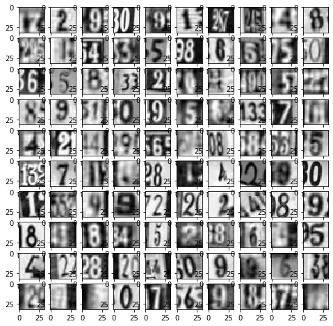

```python
fig=plt.figure(figsize=(8,8))
columns=10
rows=10
for i in range(1, columns*rows+1):
    img=X_test[i]
    fig.add_subplot(rows,columns,i)
    plt.imshow(img,cmap='gray')
plt.show()
```

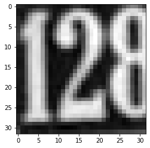

```
Label:  2
```

```python
# show the number in the train dataset
plt.imshow(X_train[0],cmap='gray')
plt.show()
print('Label: ', y_train[0])
```

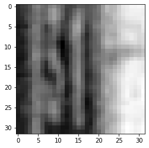

```
Label:  1
```

```python
# show the number in the test dataset
plt.imshow(X_test[0],cmap='gray')
plt.show()
print('Label: ', y_test[0])
```

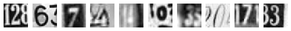

```
label for each of the above image: [2 6 7 4 4 0 3 0 7 3]
```

```python
%matplotlib inline
import matplotlib.pyplot as plt
plt.figure(figsize=(10, 1))
for i in range(10):
    plt.subplot(1, 10, i+1)
    plt.imshow(X_train[i].reshape(32,32),cmap='gray')
    plt.axis('off')
plt.show()
print('label for each of the above image: %s' % (y_train[0:10]))
```

Reshape the features from 32×32 into a single dimensional array

# Reshape features

```python
X_train =np.asarray (X_train).reshape(42000, 1024)
print(X_train.shape)
X_val = np.asarray (X_val).reshape(60000, 1024)
print(X_val.shape)
X_test = np.asarray(X_test).reshape(18000, 1024)
print(X_test.shape)
```

```
(42000, 1024)
(60000, 1024)
(18000, 1024)
```

# Normalize features

Normalize the data from 0-255 to 0-1 by dividing the inputs by 255. The denominator should be a float, else the output would become 0.

```python
print(X_train.max())
print(X_train.min())
```

```
254.9745
0.0
```

```python
X_train = X_train / 255.0
X_val = X_val / 255.0

print(X_train.max())
print(X_train.min())
```

```
0.9999
0.0
```

# One-hot encode the class vector

-convert class vectors (integers) to binary class matrix

-convert X_train and X_val

-number of classes: 10

```python
print(y_train[8])
y_train = tf.keras.utils.to_categorical(y_train, num_classes=10)
y_test = tf.keras.utils.to_categorical(y_test, num_classes=10)
y_val = tf.keras.utils.to_categorical(y_val, num_classes=10)
print(y_train[8])
```

```
7
[0. 0. 0. 0. 0. 0. 0. 1. 0. 0.]
```

# Implementing Neural Network

```python
##Initialize the Artificial Neural Network Classifier
model = Sequential()
```

```python
# Input Layer
#Adding Input layer and activation functions ReLU
model.add(Dense(512, kernel_initializer='he_normal',input_shape = (1024, )))
#Adding Activation function
model.add(Activation('relu'))

#Hidden Layer 1
#Adding first Hidden layer
model.add(Dense(256, kernel_initializer='he_normal'))
#Adding Activation function
model.add(Activation('relu'))

#Hidden Layer 2
#Adding second Hidden layer
model.add(Dense(128, kernel_initializer='he_normal'))
#Adding Activation function
model.add(Activation('relu'))

#Hidden Layer 3
#Adding third Hidden layer
model.add(Dense(64, kernel_initializer='he_normal'))
#Adding Activation function
model.add(Activation('relu'))

#Hidden Layer 4
#Adding fourth Hidden layer
model.add(Dense(32, kernel_initializer='he_normal'))
#Adding Activation function
model.add(Activation('relu'))

# Output Layer
#Adding output layer which is of 10 nodes (digits)
model.add(Dense(10))
#Adding Activation function
# Here, we are using softmax function because we have multiclass classsification
model.add(Activation('softmax'))
```

```python
model.summary()
```

```
Model: "sequential_1"
_________________________________________________________________
Layer (type)                 Output Shape              Param #
=================================================================
dense_1 (Dense)              (None, 512)               524800
_________________________________________________________________
activation_1 (Activation)    (None, 512)               0
_________________________________________________________________
dense_2 (Dense)              (None, 256)               131328
_________________________________________________________________
activation_2 (Activation)    (None, 256)               0
_________________________________________________________________
dense_3 (Dense)              (None, 128)               32896
_________________________________________________________________
activation_3 (Activation)    (None, 128)               0
_________________________________________________________________
dense_4 (Dense)              (None, 64)                8256
_________________________________________________________________
activation_4 (Activation)    (None, 64)                0
_________________________________________________________________
dense_5 (Dense)              (None, 32)                2080
_________________________________________________________________
activation_5 (Activation)    (None, 32)                0
_________________________________________________________________
dense_6 (Dense)              (None, 10)                330
_________________________________________________________________
activation_6 (Activation)    (None, 10)                0
=================================================================
Total params: 699,690
Trainable params: 699,690
Non-trainable params: 0
_________________________________________________________________
```